# Associação entre o crecimento do coral e variáveis fluvio terrestres

Pamela M. Ch. Solano

# 1 Preliminar

2. Uma outra hipótese, relacionada, é que os corais registraram as duas fases reconhecidas pelos hidrólogos, na descarga do Amazonas (1997-2004 vs 2005-2017).

Resposta: Se já foi provado pelos hidrólogos a presença de duas fases então, não precisa se preocupar.

- Esses problemas centrais foram endereçados com correlações (Spearman - dúvida),
- PCA e pela regressão que vc sugeriu maisrecentemente.

# 2 Objetivo 1

- 1. verificar se houve mudança no crescimento (2 fases?), mas sem enveredar por **séries temporais**, visto que o período coberto pelo nosso registro é um tanto limitado. Como a questão das duas fases hidrológicas estábem assentada na literatura, talvez valha simplesmente apresentar um boxplot e um teste t ou U (?). Adiferença no crescimento é muito pequena.

**Resposta 1) É necessário justificar que nesta primeira análise não vamos incluir a dependência temporal por serem poucos anos**

- Dados!

```r
TE_SEM_ENV_MCSS_2%>%str
```

```
## tibble [41 x 21] (S3: spec_tbl_df/tbl_df/tbl/data.frame)
##  $ Year     : num [1:41] 1997 1997 1998 1998 1999 ...
##  $ Semester : num [1:41] 1 2 1 2 1 2 1 2 1 2 ...
##  $ MC_LE    : num [1:41] 0.1476 0.1279 0.0295 0.1181 0.0787 ...
##  $ SS_LE    : num [1:41] NA NA NA NA NA NA NA NA NA NA ...
##  $ Mg       : num [1:41] 0.00401 0.0043 0.00408 0.00454 0.00367 ...
##  $ Sr       : num [1:41] 0.00885 0.00889 0.00911 0.00919 0.00917 ...
##  $ U        : num [1:41] 9.34e-07 9.08e-07 1.09e-06 1.38e-06 1.32e-06 ...
##  $ Ba       : num [1:41] 4.09e-06 4.07e-06 4.13e-06 4.23e-06 4.04e-06 ...
##  $ Y        : num [1:41] 6.65e-08 6.76e-08 9.09e-08 1.49e-07 1.43e-07 3.02e-07 2.26e-07 1.17e-07 1.11e-07 5.94e-08 ...
##  $ Mn       : num [1:41] 4.75e-07 4.49e-07 4.93e-07 5.54e-07 3.63e-07 3.78e-07 3.52e-07 3.73e-07 3.36e-07 4.23e-07 ...
##  $ Mg,ss    : num [1:41] NA NA NA NA NA NA NA NA NA NA ...
##  $ Sr,ss    : num [1:41] NA NA NA NA NA NA NA NA NA NA ...
##  $ U,ss     : num [1:41] NA NA NA NA NA NA NA NA NA NA ...
##  $ Ba,ss    : num [1:41] NA NA NA NA NA NA NA NA NA NA ...
##  $ Mn,ss    : num [1:41] NA NA NA NA NA NA NA NA NA NA ...
##  $ Y,ss     : num [1:41] NA NA NA NA NA NA NA NA NA NA ...
##  $ Discharge: num [1:41] 2.08e+09 1.31e+09 1.65e+09 1.34e+05 2.11e+05 ...
##  $ SST      : num [1:41] NA NA NA NA NA NA NA NA NA NA ...
##  $ Kd490    : num [1:41] NA NA NA NA NA NA NA NA NA NA ...
##  $ iPAR     : num [1:41] NA NA NA NA NA NA NA NA NA NA ...
##  $ Chl,a    : num [1:41] NA NA NA NA NA NA NA NA NA NA ...
##  - attr(*, "spec")=
##   .. cols(
##   ..   Year = col_double(),
##   ..   Semester = col_double(),
##   ..   MC_LE = col_double(),
##   ..   SS_LE = col_double(),
##   ..   Mg = col_double(),
##   ..   Sr = col_double(),
##   ..   U = col_double(),
##   ..   Ba = col_double(),
##   ..   Y = col_double(),
##   ..   Mn = col_double(),
##   ..   `Mg,ss` = col_double(),
##   ..   `Sr,ss` = col_double(),
##   ..   `U,ss` = col_double(),
##   ..   `Ba,ss` = col_double(),
##   ..   `Mn,ss` = col_double(),
##   ..   `Y,ss` = col_double(),
##   ..   Discharge = col_number(),
##   ..   SST = col_double(),
##   ..   Kd490 = col_double(),
##   ..   iPAR = col_double(),
##   ..   `Chl,a` = col_number()
##   .. )
```

```r
#MC--
#H0: y ~ normal (é)
shapiro.test(CC$MC_LE%>%as.numeric()) # se rejeita que seja normal: não assumimos normalidade (p-value é menor do que 0.05)
```

```
##
##  Shapiro-Wilk normality test
##
## data:  CC$MC_LE %>% as.numeric()
## W = 0.92508, p-value = 0.009952
```

- MC_LE (abundâncias): Para MC não são normais, p-valor<0.05 (pvalor=0.009952), por tanto se rejeita a suposição de normalidade.

```r
# test Mann-Whitney-Wilcoxon Test
#H0: mu1=mu2
wilcox.test(MC_LE ~ pareado, data=CC)  # são iguais os crecimentos antes e depois (p-value não é menor do que 0.05)
```

```
##
##  Wilcoxon rank sum test with continuity correction
##
## data:  MC_LE by pareado
## W = 249.5, p-value = 0.1898
## alternative hypothesis: true location shift is not equal to 0
```

- Desde que nossa variável resposta não é normal usamos o: Mann-Whitney-Wilcoxon Test, para verificar diferença entre as abundâncias antes e depois do ano 2004.
- Conclusão: As abundâncias antes e depois do ano 2004 são iguais, p-value não é menor do que 0.05 (p-value = 0.1898).

# 3 Objetivo 2

- 2. verificar se o crescimento é influenciado por algumas das variáveis ambientais que medimos,especialmente i) deságue, ii) temperatura. E aqui entraria o GAM (ou outra abordagem).
- 2.a) Calcular as Crescimento relativo
- 2.b) regressão(Anomalia coral ~ tempera+deságue+temperatura*deságue)

```r
Reg.Dados
```

| CresRelat_MC | CresRelat_SS | SST | Discharge |
| --- | --- | --- | --- |
| -0.46428571 | NaN | NaN | 1696866667 |
| 0.46666667 | NaN | NaN | 826150259 |
| 0.45454545 | NaN | NaN | 805022092 |
| -0.46875000 | NaN | NaN | 830015617 |
| 0.47058824 | NaN | NaN | 1025156131 |
| -0.28000000 | NaN | NaN | 177875 |
| 0.99999999 | NaN | 27.205 | 934910234 |
| -0.61111111 | NaN | 27.220 | 1643250000 |
| 1.64285713 | NaN | 27.495 | 988146199 |
| -0.16588772 | NaN | 27.420 | 1845175000 |

[output cut: 11 more lines]

## 3.1 Crescimento relativo MC - modelo

```r
#MC
#H0: y ~ normal (é)
shapiro.test((Reg.Dados$CresRelat_MC)[-21]) # se rejeita que seja normal: não assumimos normalidade (p-value é menor do que 0.05)
```

```
##
##  Shapiro-Wilk normality test
##
## data:  (Reg.Dados$CresRelat_MC)[-21]
## W = 0.8736, p-value = 0.0136
```

- Anomalia para MC não é normal (p-value = 0.0136)
- então vamos fazer correlações (Spearman pois não é normal) para avaliar se existe relação entre Anomalia coral vs tempera,deságue.
- Repare que o tamanho de amostra é pequeno demais (20 valores).

## 3.2 Spearman correlation para Anomalia MC vs “SST” e “discharge”

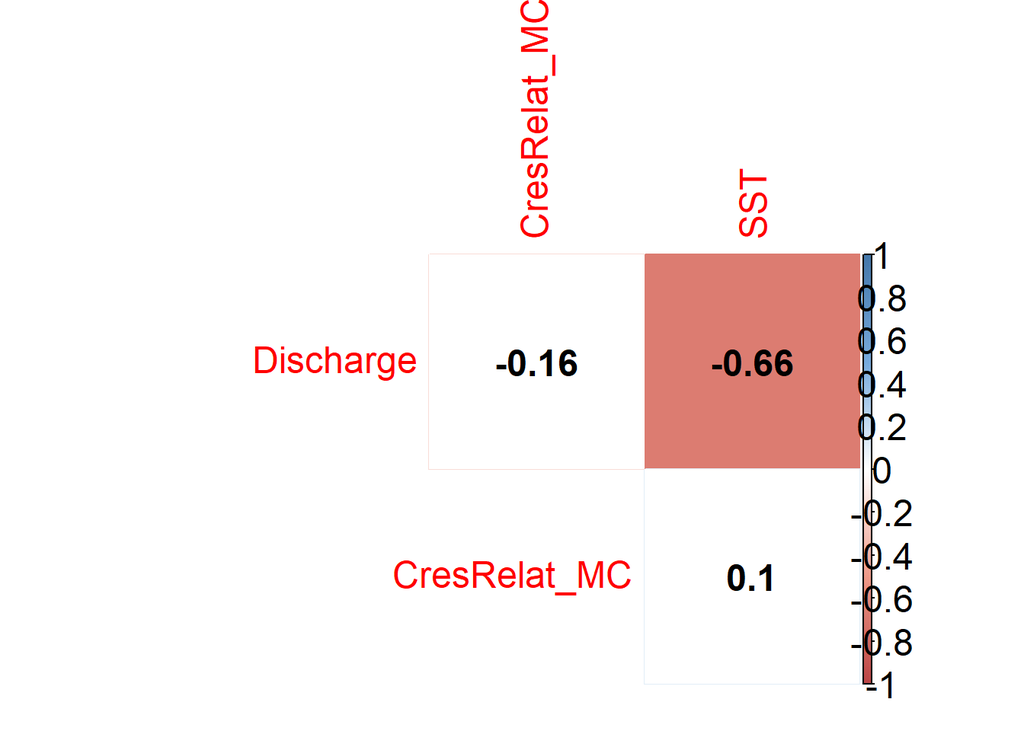

```r
corrplot(cor_matrix$r, method="color",col=col(200),
         type="upper", order="hclust",diag=F,
         addCoef.col = "black", # Add coefficient of correlation
         addrect=2,
         number.cex = 1.5, tl.cex = 1.5,cl.cex = 1.5,
         p.mat = cor_matrix$P, sig.level = 0.05, insig = "blank",
         mar=c(0,0,0,0) )
```

- Se é colorido, então existe correlação significativa!
- não tem relação linear entre anomalias MC e SST / deságue!

## 3.3 Crescimento relativo SS - modelo

```r
#SS
#H0: y ~ normal (é)
shapiro.test((Reg.Dados$CresRelat_SS)[12:20]) # não se rejeita que seja normal: assumimos normalidade (p-value não é menor do que 0.05)
```

```
##
##  Shapiro-Wilk normality test
##
## data:  (Reg.Dados$CresRelat_SS)[12:20]
## W = 0.96076, p-value = 0.8062
```

- Anomalia para SS pode ser assumida normal (p-value = 0.8062)
- então vamos fazer correlações (Pearson pois é normal) para avaliar se existe relação entre Anomalia SS vs tempera,deságue.
- Repare que o tamanho de amostra é pequeno demais (9 valores).

## 3.4 Pearson correlation para Anomalia SS vs “SST” e “discharge”

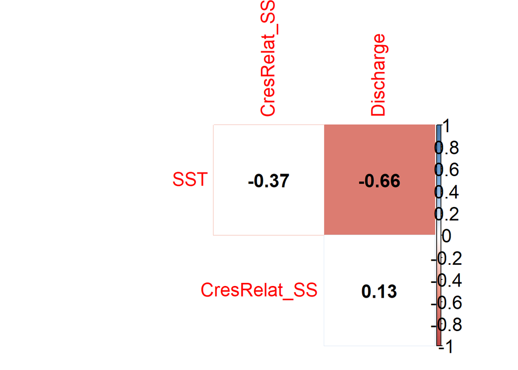

```r
corrplot(cor_matrix$r, method="color",col=col(200),
         type="upper", order="hclust",diag=F,
         addCoef.col = "black", # Add coefficient of correlation
         addrect=2,
         number.cex = 1.5, tl.cex = 1.5,cl.cex = 1.5,
         p.mat = cor_matrix$P, sig.level = 0.05, insig = "blank",
         mar=c(0,0,0,0) )
```

- Se é colorido, então existe correlação linear significativa!
- não tem relação linear entre anomalias SS e SST / deságue!